# Indexing and cleaning data

INFO 5871-001

Based on materials by

[Brian C. Keegan, Ph.D.](http://brianckeegan.com/)  
[Assistant Professor, Department of Information Science](https://www.colorado.edu/cmci/people/information-science/brian-c-keegan)  
University of Colorado Boulder

Copyright and distributed under an [MIT License](https://opensource.org/licenses/MIT)

### Imports

```python
import pandas as pd
import numpy as np
%matplotlib inline
import matplotlib.pyplot as plt
import seaborn as sns
import scipy.stats as st

np.random.seed(20190930)
```

### Read in data

Use pandas's `read_csv` function to read in "den_passengers.csv"

```python
passengers_df = pd.read_csv('den_passengers.csv')
passengers_df.head()
```

|  | Month | Total | American | Cargo | Delta | Frontier | Other | Southwest | United | United Express | Grand Total |
| --- | --- | --- | --- | --- | --- | --- | --- | --- | --- | --- | --- |
| 0 | 1995-02-01 | NaN | 5833 | 0 | 4805 | 1434 | 8625 | NaN | 47230 | 2635 | 70562 |
| 1 | 1995-03-01 | NaN | 228196 | 0 | 200964 | 36703 | 245171 | NaN | 1962445 | 169190 | 2842669 |
| 2 | 1995-04-01 | NaN | 184229 | 0 | 157853 | 40050 | 191393 | NaN | 1724836 | 124351 | 2422712 |
| 3 | 1995-05-01 | NaN | 187990 | 0 | 162622 | 41403 | 171425 | NaN | 1833305 | 135800 | 2532545 |
| 4 | 1995-06-01 | NaN | 229348 | 0 | 198499 | 43754 | 186030 | NaN | 1975754 | 170033 | 2803418 |

### Check the packaging

The data should start in February 1995 and go through July 2019.

```python
passengers_df.Month.describe()
```

```
count            295
unique           294
top       2018-05-01
freq               2
Name: Month, dtype: object
```

Use [`pd.to_datetime`](https://pandas.pydata.org/pandas-docs/stable/reference/api/pandas.to_datetime.html) to convert the "Month" column into valid datetime objects. (Alternatively, use one of the function calls in `read_csv` to do this).

```python
passengers_df.Month = pd.to_datetime(passengers_df.Month)
passengers_df.Month.describe()
```

```
count                     295
unique                    294
top       2018-05-01 00:00:00
freq                        2
first     1995-02-01 00:00:00
last      2019-07-01 00:00:00
Name: Month, dtype: object
```

### Clean up the data

Make the "Month" column the index using the [`.set_index`](https://pandas.pydata.org/pandas-docs/stable/reference/api/pandas.DataFrame.set_index.html) method.

```python
passengers_df = passengers_df.set_index('Month')
```

Drop the columns for "Total", "Cargo", and "Grand Total".

```python
passengers_df.drop(['Total','Cargo','Grand Total'], axis=1, inplace=True)
```

Remove the partial years from the data. Use `.loc`

```python
pass_df = passengers_df.loc['1996-01-01':'2018-12-01',]
print(pass_df.shape)
pass_df.head()
```

```
(277, 7)
```

| Month | American | Delta | Frontier | Other | Southwest | United | United Express |
| --- | --- | --- | --- | --- | --- | --- | --- |
| 1996-01-01 | 190913 | 187742 | 85574 | 110799 | NaN | 1722852 | 177437 |
| 1996-02-01 | 185774 | 188882 | 77753 | 132357 | NaN | 1730614 | 183843 |
| 1996-03-01 | 235231 | 220495 | 100527 | 158944 | NaN | 2062532 | 194721 |
| 1996-04-01 | 172746 | 179340 | 85674 | 120648 | NaN | 1758331 | 138287 |
| 1996-05-01 | 171146 | 187344 | 90060 | 121000 | NaN | 1890598 | 139383 |

## Question 1: American vs Delta

What proportion of months did American have more passengers than Delta? Based on a sample of the data, can we estimate accurately?

We know the "real" answer, because we have all the data, so this is just an exercise.

### Prepare

- Identify the parameter of interest
- List hypotheses
- Identify the signifance level
- Identify $\hat{p}$ and n.
- Parameter of interest: proportion of months in which American > Delta
- H0: The fraction is 50%. No difference in the airlines.
- H1: There is a significant difference
- Significance level 95% $\alpha$ = 0.05
- n = 100

Computing $\hat{p}$

```python
american_more = pass_df['American'] > pass_df['Delta']
n = 100
american_sam = american_more.sample(n)
p_hat = american_sam.sum() / n
```

### Check.

- Verify conditions to ensure $\hat{p} is nearly normal under H0. For one-proportion hypothesis tests, use the null value to check the success-failure condition.

```python
print (n*p_hat > 10)
print (n*(1-p_hat) > 10)
```

```
True
True
```

### Calculate.

- If the conditions hold, compute the standard error, again using p0,
- compute the Z-score,
- identify the p-value.

```python
se = np.sqrt(p_hat*(1-p_hat)/n)
z = (0.5 - p_hat)/se
print(z)
```

```
-2.4722569302909876
```

```python
p = 2 * st.norm.cdf(z)
print (p)
```

```
0.013426298293326975
```

### Conclude.

Evaluate the hypothesis test by comparing the p-value to $\alpha$, and provide a conclusion in the context of the problem.

### Compare with reality

```python
american_more.sum() / american_more.shape[0]
```

```
0.6534296028880866
```

Our sampling gave an accurate result.

## Question 2: How have ridership patterns at DIA changed across airlines over time?

### Make a plot

Visualize the monthly passenger data for each of the airlines.

Move the legend to the right for greater readability

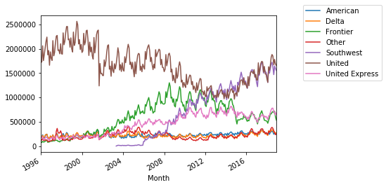

```python
ax = pass_df.plot()
plt.legend(bbox_to_anchor=(1.1, 1.1), bbox_transform=ax.transAxes)
```

### Melt the data

Use pandas's [`melt`](https://pandas.pydata.org/pandas-docs/stable/reference/api/pandas.melt.html) function on your cleaned `passengers_df` to make it tidier. Note that you'll likely need to use `.reset_index()` on `passengers_df` to turn the "Month" index back into a column. Rename the columns so they're more interpretable too.

Your melted data should look something like this:

[output not shown]

```python
pass_df = pass_df.reset_index()
pass_melt = pd.melt(pass_df, id_vars=['Month'])
pass_melt.columns = ['Month', 'Airline', 'Count']

pass_melt.head()
```

|  | Month | Airline | Count |
| --- | --- | --- | --- |
| 0 | 1996-01-01 | American | 190913.0 |
| 1 | 1996-02-01 | American | 185774.0 |
| 2 | 1996-03-01 | American | 235231.0 |
| 3 | 1996-04-01 | American | 172746.0 |
| 4 | 1996-05-01 | American | 171146.0 |

### Visualize the melted data

Use `FacetGrid` seaborn's [`lineplot`](https://seaborn.pydata.org/generated/seaborn.lineplot.html) to make a time series plot on the melted data.

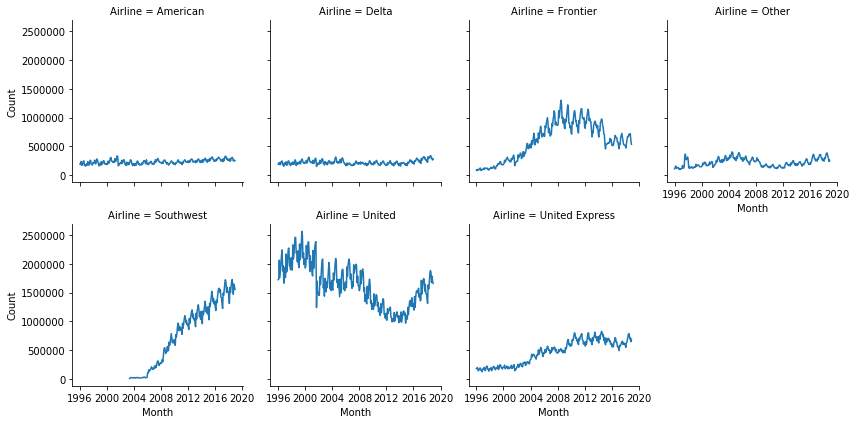

```python
g = sns.FacetGrid(pass_melt, col='Airline', col_wrap=4)
g.map(sns.lineplot, 'Month', 'Count')
```

Create a new column "Month_num" in your melted data: January is 1, February is 2, *etc*. If you use StackOverflow to [find a solution](https://stackoverflow.com/a/25149272/1574687), make sure to reference it.

```python
pass_melt['Month_num'] = pass_melt['Month'].dt.month
```

Use seaborn's [catplot](https://seaborn.pydata.org/generated/seaborn.catplot.html) to make a plot with "Month" on the x-axis and "Count" on the y-axis. What are some interesting patterns? What could be driving it?

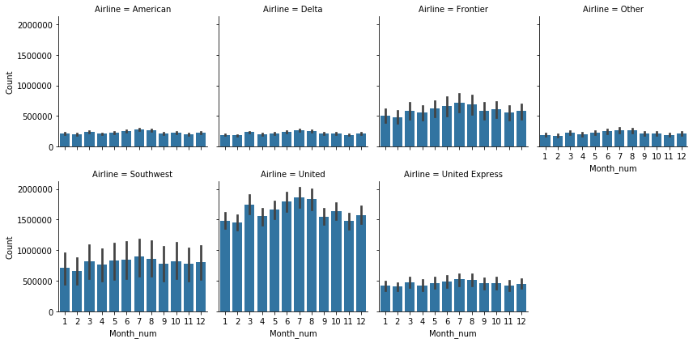

```python
g = sns.FacetGrid(pass_melt, col='Airline', col_wrap=4)
g.map(sns.barplot, 'Month_num', 'Count', order=range(1,13))
```